# Documentazione

Andrea & Ottavia

2022-11-10

# 1 Files

- *Class and Methods.R* e *Class and Methods extension.R* contengono le definizioni delle classi e dei metodi presentati in seguito.
- *Shapes_list.R* contiene le forme sviluppate di default.
- *Rules_27102022.R* contiene le regole per la creazone delle matrici.

# 2 Classe campo

La classe `field` contiene le informazioni neccessarie per plottare il contenuto di una cella della matrice.

```r
field <- list(
  shape = NULL,
  size.x = list(),
  size.y = list(),
  rotation = list(),
  pos.x = list(),
  pos.y = list(),
  lty =list(),
  lwd = list(),
  num = list(),
  nv = list(),
  shade =list(),
  visible = NULL,
  tag = list()
)
```

- `shape` è un vettore contente stringhe di caratteri, ogni elemento della stringa indica la forma che si vuole sviluppare, per esempio `c('circle','square')`
- `size.x` e `size.y` un vettore o un scalare che danno informazione per il semi-asse maggiore e minore del elisse entro il quale è inscritto il poligono (corrispondono a `radius.x` e `radius.y` del pacchetto `DescTools`)

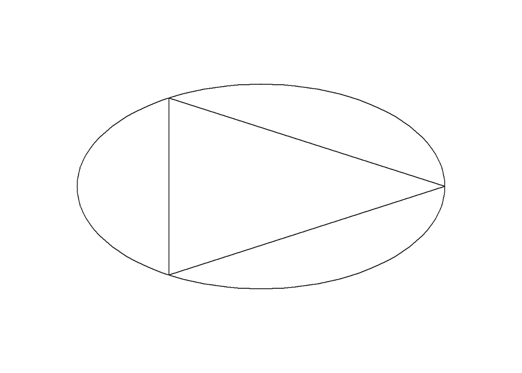

```r
library(DescTools)
Canvas(c(-5,5),c(-5,5)) # non è necessario il secondo c(-5,5) basta Canvas(c(-5,5))
DrawRegPolygon(x = 0, y = 0, radius.x=9,radius.y = 5, nv = 100)
DrawRegPolygon(x = 0, y = 0, radius.x=9,radius.y = 5, nv = 3)
```

- `rotation` angolo di rotazione in radianti (corrisponde a `rot` del pacchetto `DescTools`)
- `x` e `y` un vettore delle coordinate xy del centro del polygono (corrispondono a `x` e `y` del pacchetto `DescTools`)
- `lty` e `lwd` rispettivamente il tipo di linea per il perimetro e lo spessore della stessa. Le figure di default hanno `lty=1` e `lwd=2` (corrispondono a `lty` e `lwd` del pacchetto `DescTools`)
- `num` il numero di volte che un oggetto è ripetuto sulla cella (più un desiderata che altro al momento)
- `nv` il numero di vertici del poligono (per cerchi/elipsi `nv = 100`)
- `shade` è il riempimento monocromatico di una forma
- `visible` un vettore binario che contiene un 1 se la forma nella posizione relativa deve venire disegnata, uno 0 se non deve venire disegnata. Per esempio `list(shapes=c('circle','square'), visible = c(0,1))` plottera solo il quadrato e non il cerchio.

# 3 Classe matrice

La classe `Raven_matrix` contiene tutte le informazioni neccessarie per classificare la creazione della matrice.

```r
Raven<-list(
    Sq1 = list(),
    Sq2 = list(),
    Sq3 = list(),

    Sq4 = list(),
    Sq5 = list(),
    Sq6 = list(),

    Sq7 = list(),
    Sq8 = list(),
    Sq9 = list(),
    hrule = list(),
    vrule = list()
  )
```

I campi da `Sq1` a `Sq9` corrispondono alle celle della matrice.

```
##      [,1]  [,2]  [,3]
## [1,] "Sq1" "Sq2" "Sq3"
## [2,] "Sq4" "Sq5" "Sq6"
## [3,] "Sq7" "Sq8" "Sq9"
```

Ogni cella della matrice andrà a contenere un oggetto di classe `field` contenente tutte le possibili forme al suo interno.

I campi `hrule` e `vrule` sono due vettori contententi le regole.

- `hrule` contiene le regole che verranno applicate secondo la logica orizzontale. L’ordine delle regole nel vettore corrisponde al ordine di applicazione.
- `vrule` contiene le regole che verranno applicate secondo la logica verticale. L’ordine delle regole nel vettore corrisponde al ordine di applicazione.

Logiche più complesse vengono ottenute tramite composizioni di orizzontale e verticale.

# 4 Forme di Default

## 4.1 Forme Geometriche

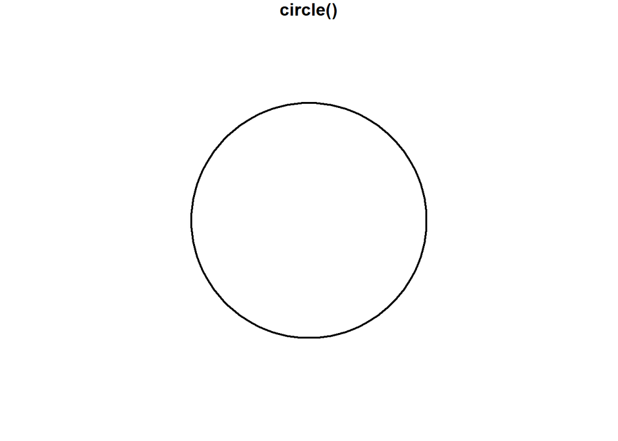

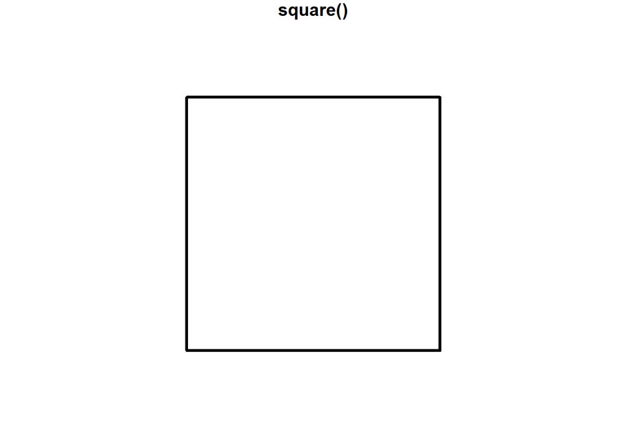

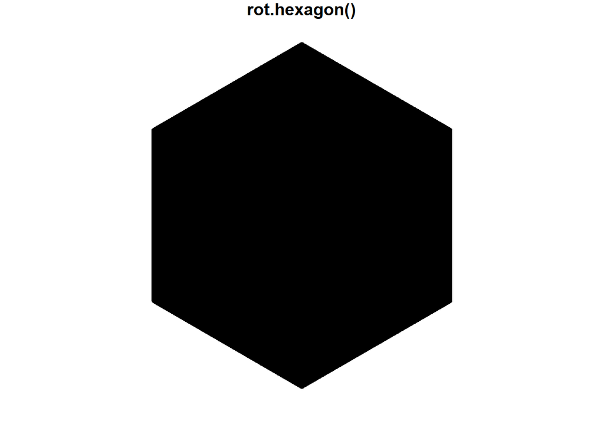

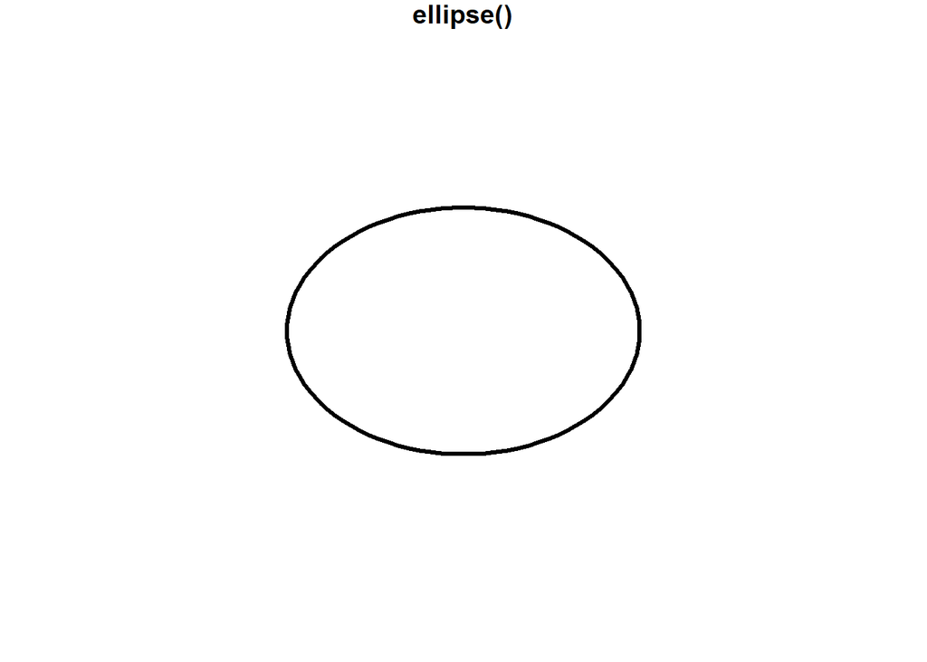

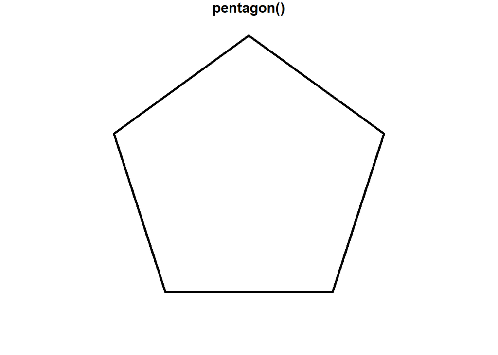

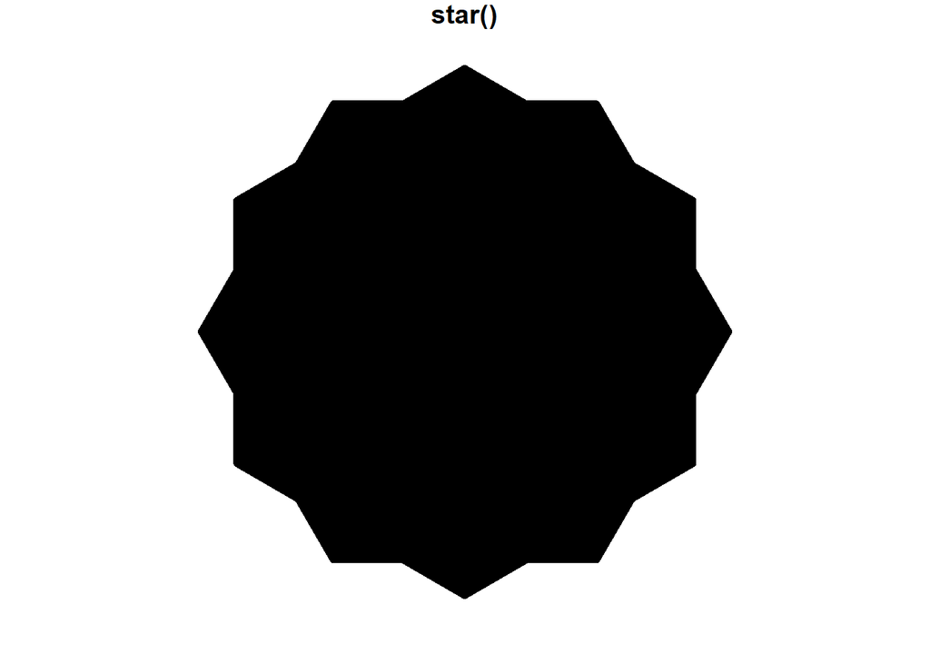

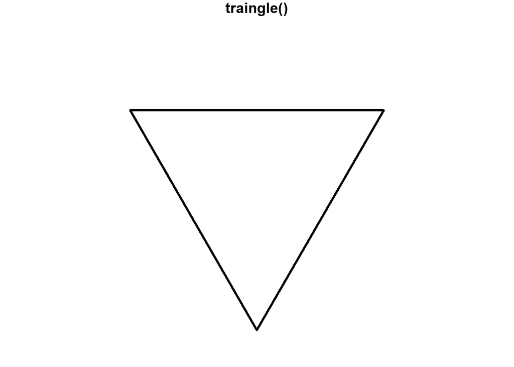

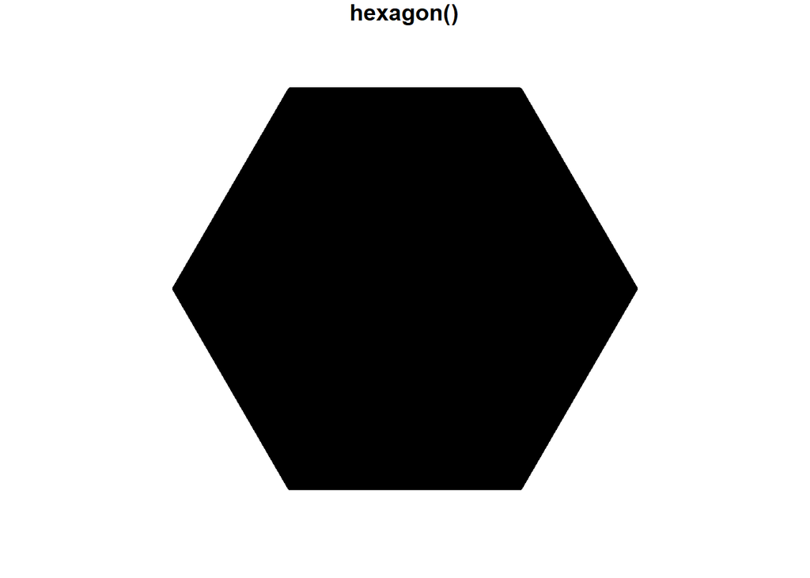

## 4.2 Segmenti

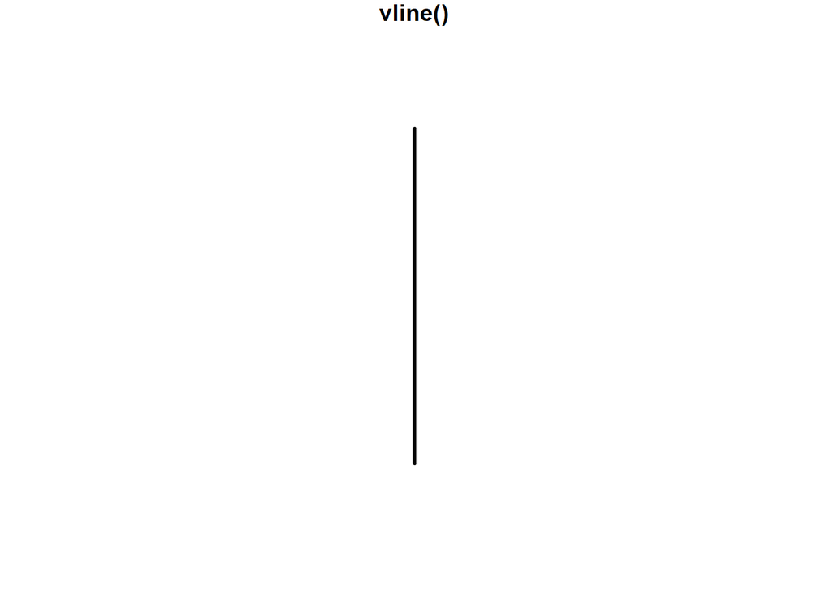

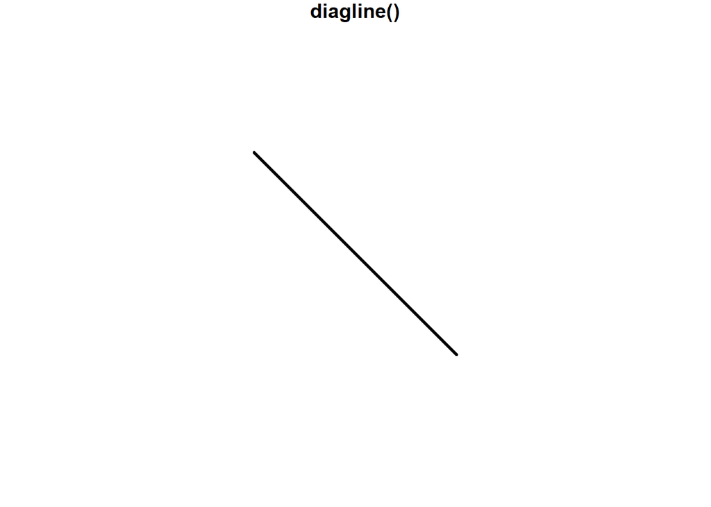

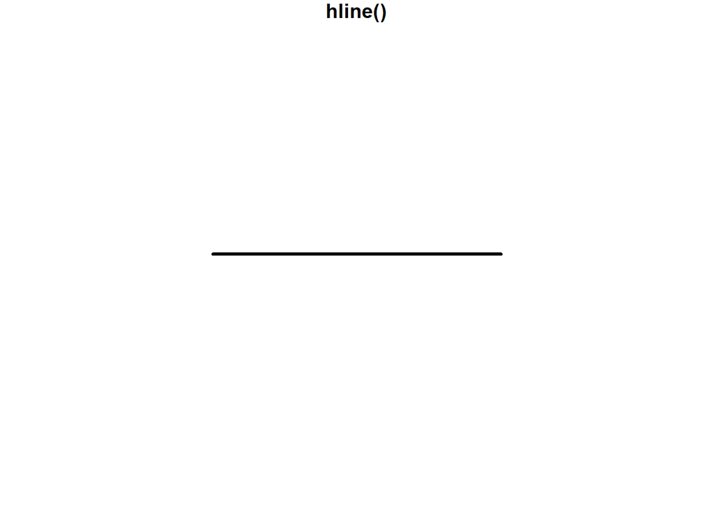

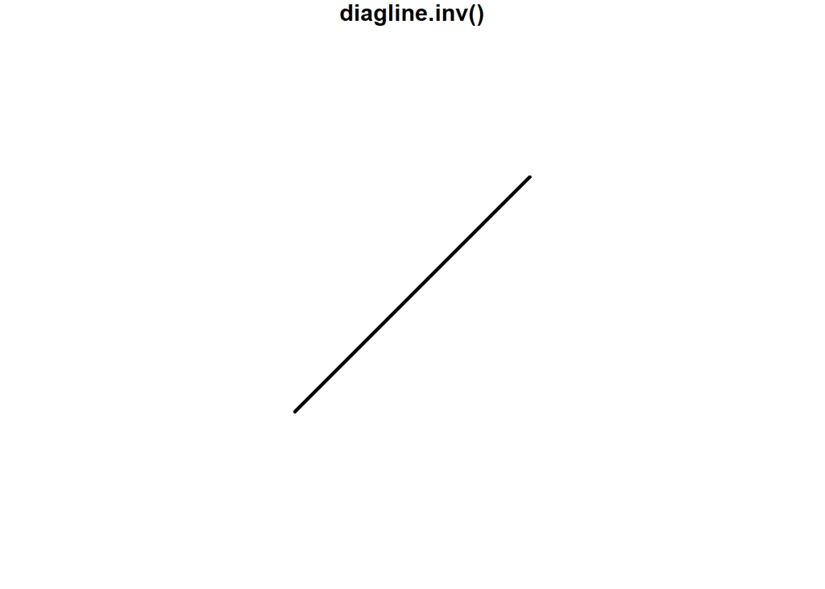

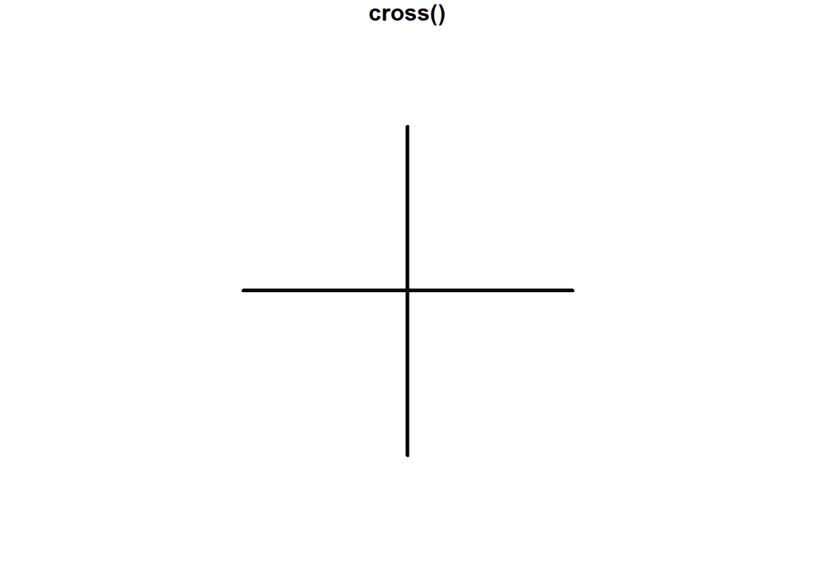

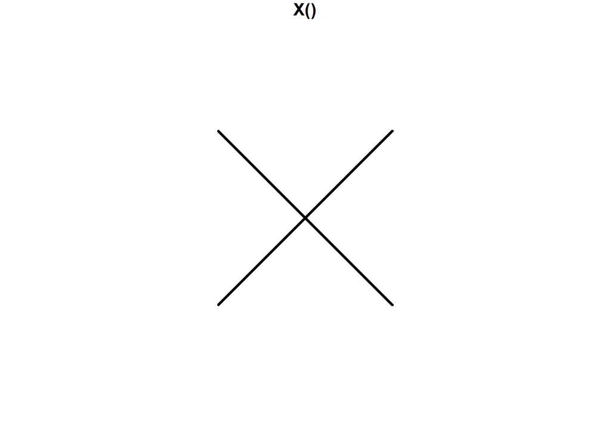

## 4.3 Archi

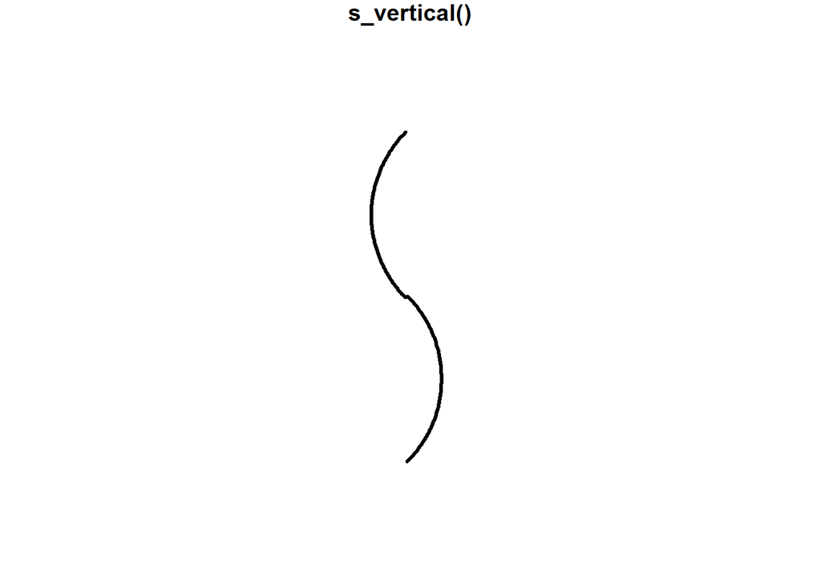

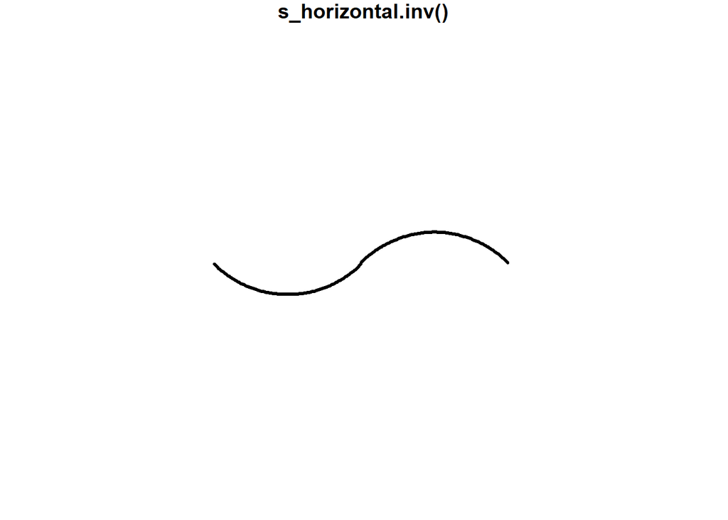

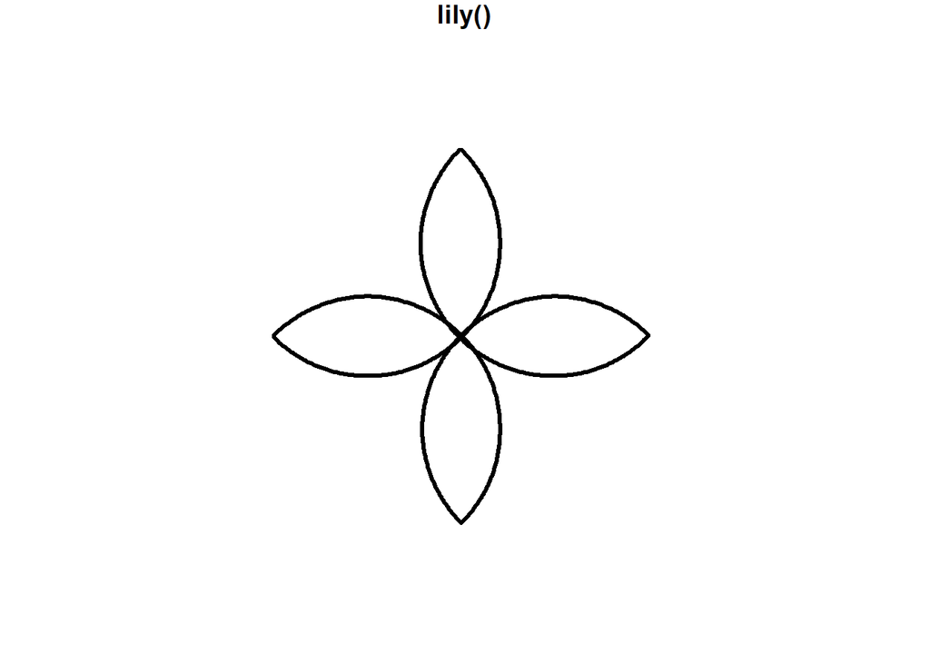

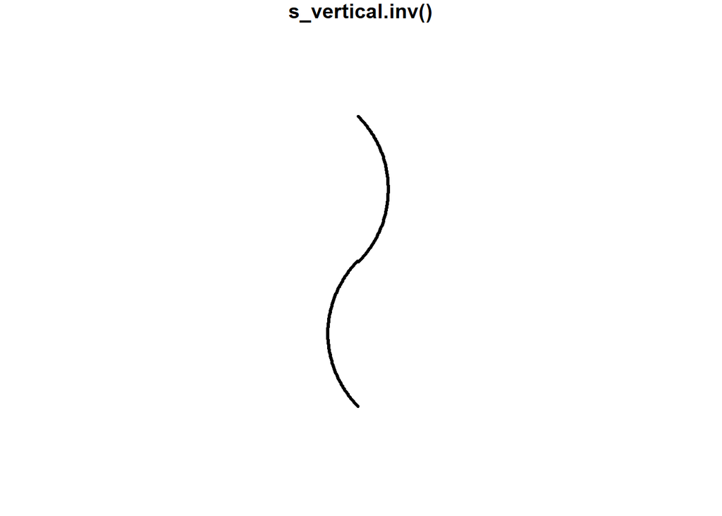

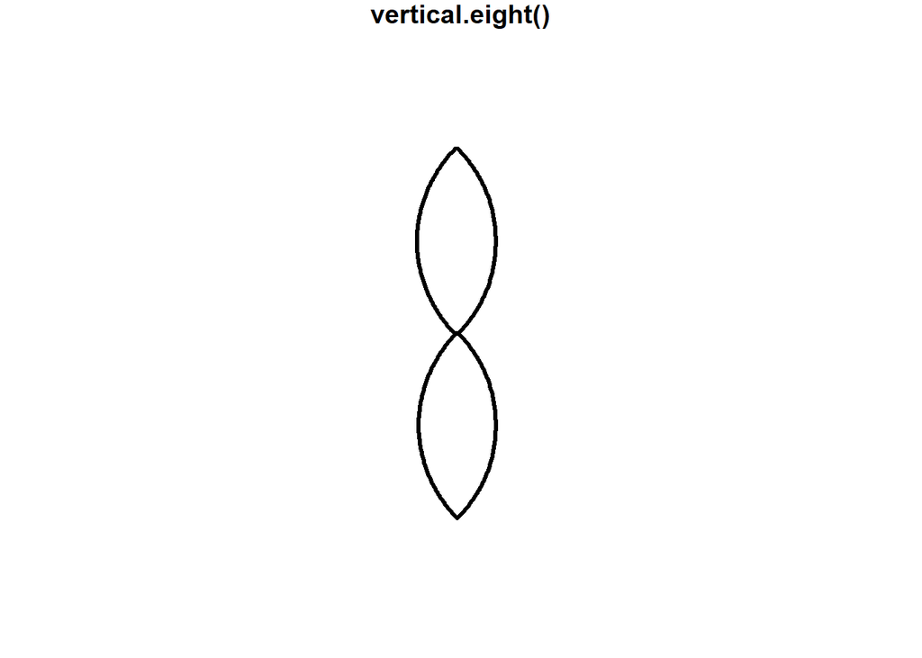

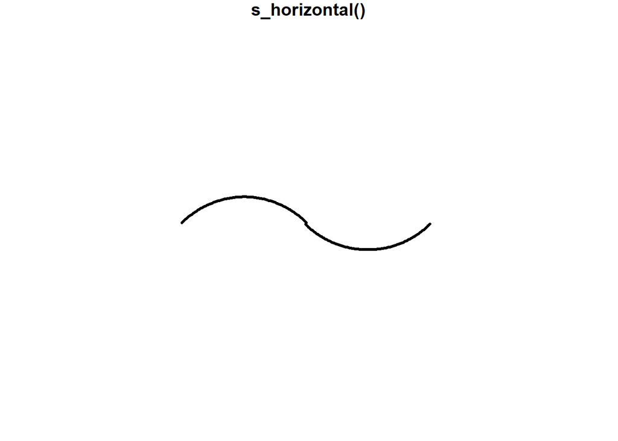

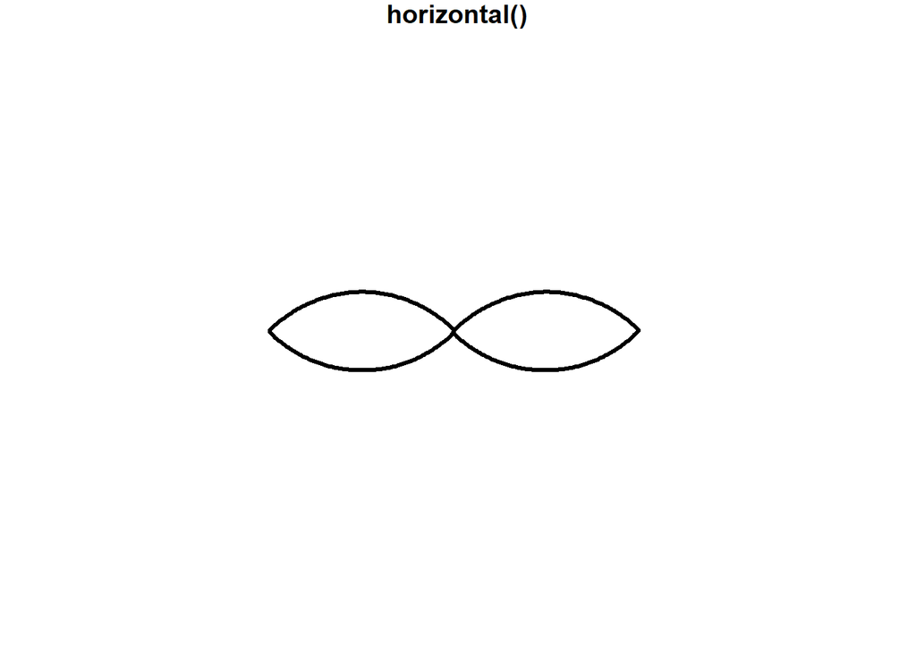

## 4.4 Forme puntinate

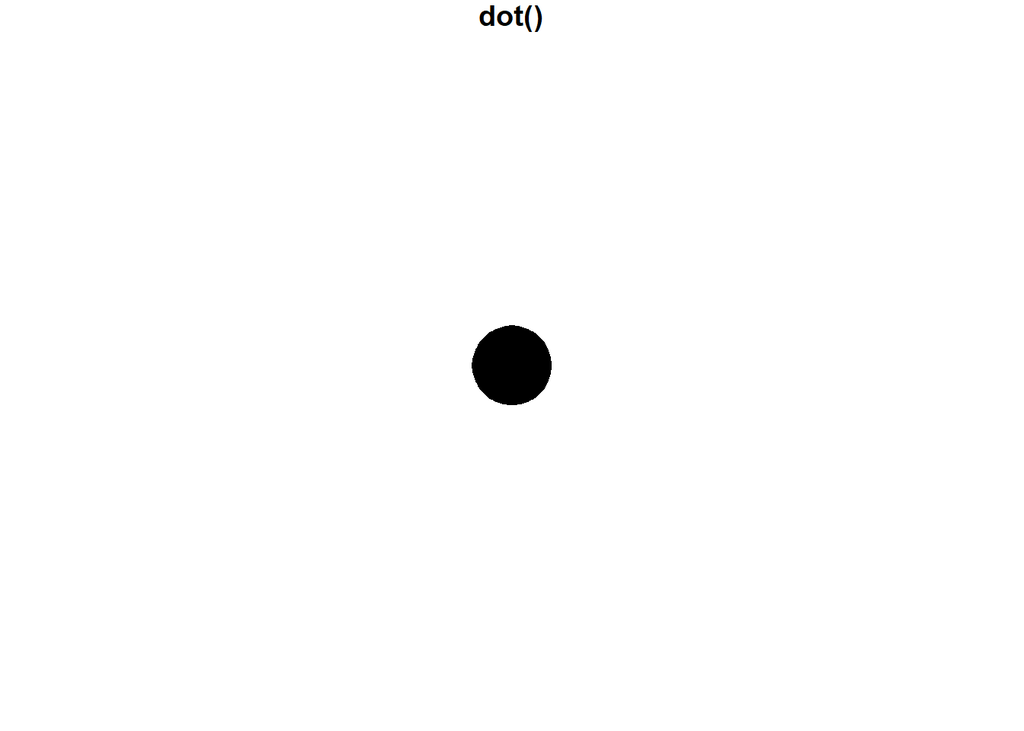

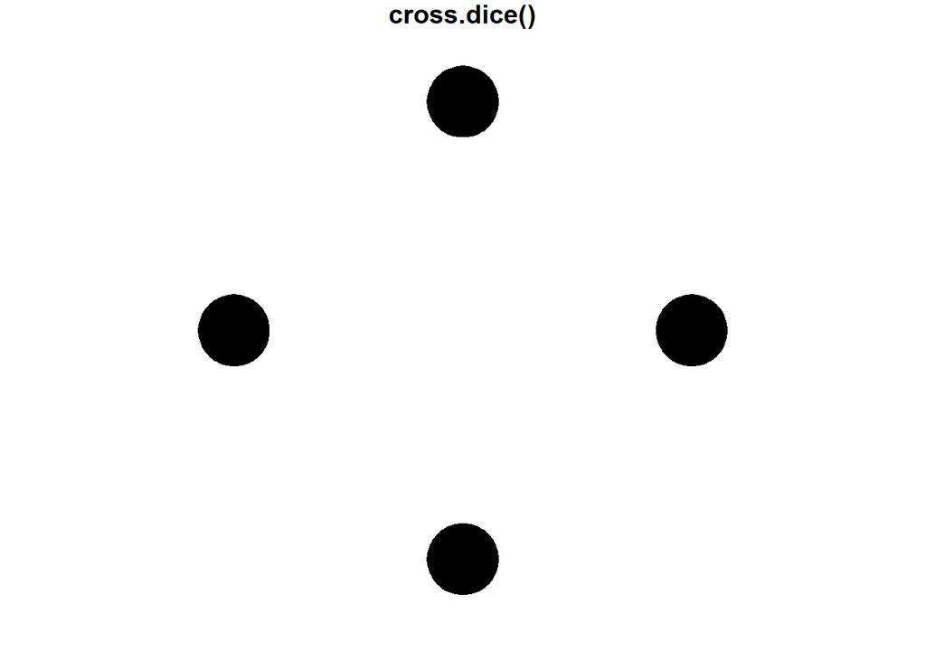

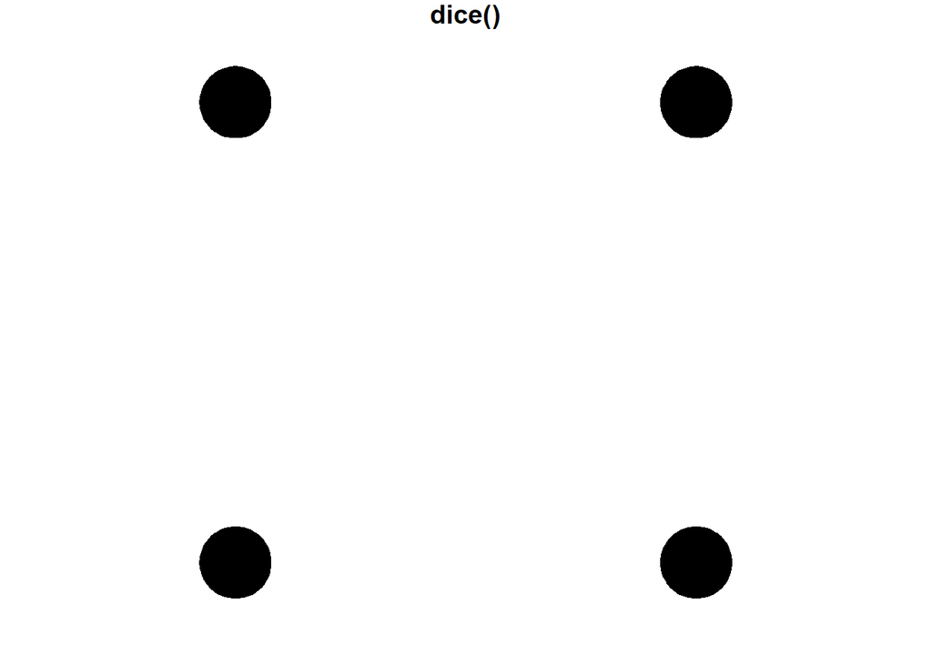

# 5 Concatenazione di Forme

La funzione `cof` concatena diversi campi esattamente secondo la stessa logica di `c()`

```r
source("Class and Methods.R")
cof(square(),circle(),pentagon())
```

```
## $shape
## [1] "square"   "circle"   "pentagon"
##
## $size.x
## $size.x[[1]]
## [1] 15
##
## $size.x[[2]]
## [1] 10
##
## $size.x[[3]]
## [1] 15
##
##
## $size.y
## $size.y[[1]]
## [1] 15
##
## $size.y[[2]]
## [1] 10
##
## $size.y[[3]]
## [1] 15
##
##
## $theta.1
## $theta.1[[1]]
## [1] 0
##
## $theta.1[[2]]
## [1] 0
##
## $theta.1[[3]]
## [1] 0
##
##
## $theta.2
## $theta.2[[1]]
## [1] 0
##
```

[output cut: 96 more lines]

```
## [1] 1 1 1
##
## $tag
## $tag[[1]]
## [1] "simple" "small"
##
## $tag[[2]]
## [1] "simple" "small"
##
## $tag[[3]]
## [1] "simple" "small"
##
##
## attr(,"class")
## [1] "field"
```

# 6 Creazione di una matrice

La funzione `Raven` crea una matrice di Raven in cui tutte le celle della matrice vengono inizializzate identiche alla cella `Sq1`, e vengono inizializzate le regole.

- `St1` classe field che contiene i campi di partenza per tutte le celle
- `hrule` vettore delle regole applicabili con logica orizzontale
- `vrule` vettore delle regole applicabili con logica verticale

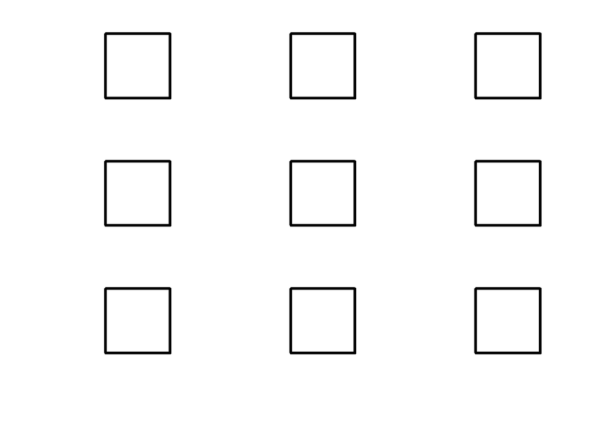

```r
M<-Raven(st1=square(),hrule=c("size"),vrule=c("identity"))
draw(M)
```

Nella matrice `M` le regole non sono ancora state applicate, infatti nel plot d’esempio i quadrati hanno tutti le stesse dimensioni.

L’estensione del metodo `apply` applica le regole presenti nella matrice a tutte le celle. Al momento applica le regole prima in riga e poi in colonna.

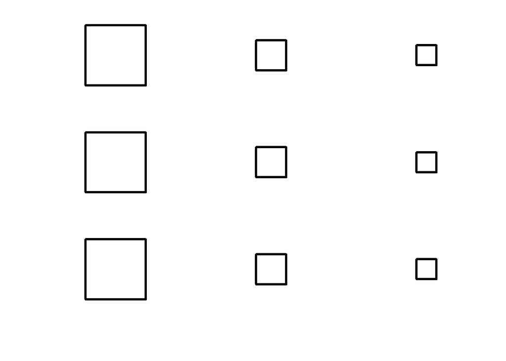

```r
M<-apply(M)
draw(M)
```

# 7 Regole (Field)

## 7.1 Rotazione

Il metodo rotazione cambia il valore `field$rotation` di rotazioni fisse con un angolo di $\frac{\pi}{4}$

- `obj` il contenuto di una cella della matrice
- `n` rappresenta l’ennesimo elemento a cui viene applicata la regola. Per esempio se la regola viene applicata orizzontalmente `n =1` per `Sq1`,`Sq4` e `Sq7`, `n =2` per `Sq2`,`Sq5` e `Sq8` e per finire `n =3` per `Sq3`,`Sq6` e `Sq9`.

```r
rotation.field<-function(obj,n,...) {
  obj$rotation[[1]]<-obj$rotation[[1]]+(n-1)*pi/4
  return(obj)
}
```

La rotazione può essere applicata con le regole orizzontali, verticali e diagonalmente da basso a sinistra a alto-destra (TL-LR) applicando prima in orizzontale poi verticale.

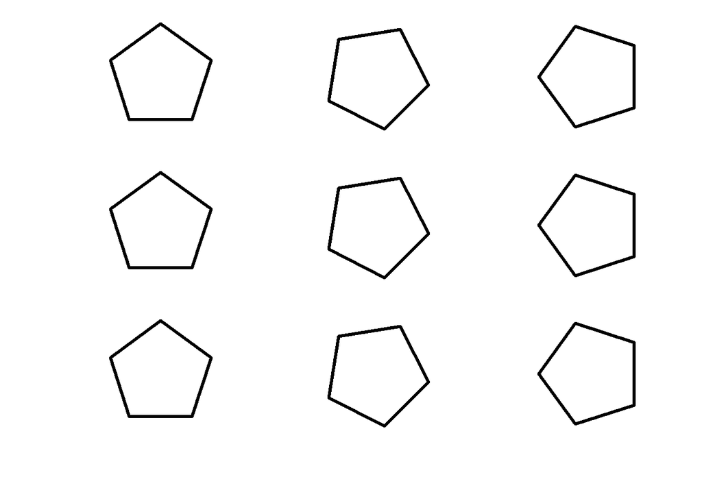

```r
#Horizontal
M<-apply(Raven(st1=pentagon(),hrule=c("rotation"),vrule=c("identity")))
draw(M)
```

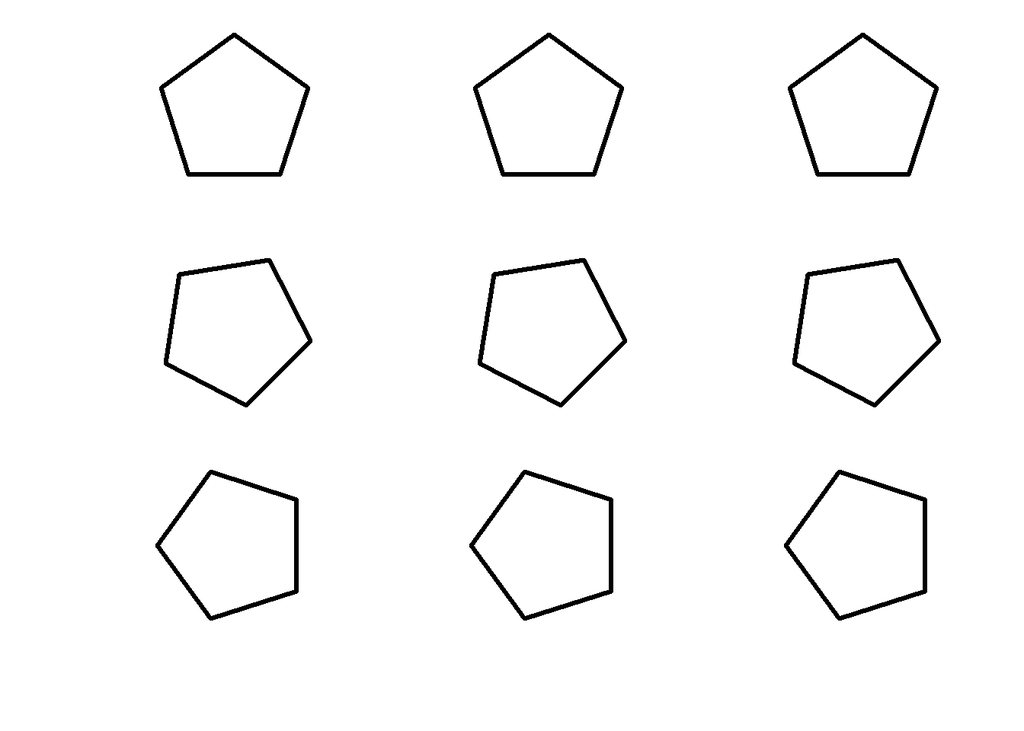

```r
#Vertical
M<-apply(Raven(st1=pentagon(),hrule=c("identity"),vrule=c("rotation")))
draw(M)
```

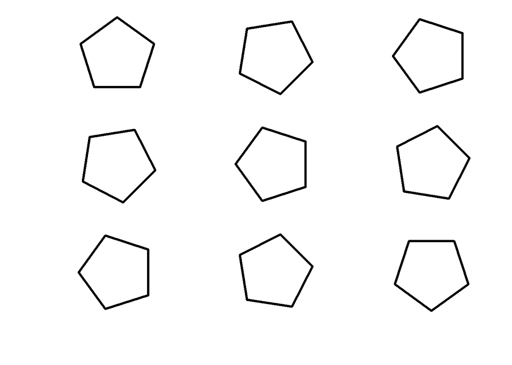

```r
# Top Left Low Right
M<-apply(Raven(st1=pentagon(),hrule=c("rotation"),vrule=c("rotation")))
draw(M)
```